# The spreading of misinformation across borders and languages on Twitter

AACL 2022

## Misinformation

- **Misinformation**: false, but not created or shared with the intention of causing harm.
- **Disinformation**: deliberately created to mislead, harm, or manipulate a person, social group, organization, or country.
- **Malinformation**: based on fact, but used out of context to mislead, harm, or manipulate.

Cybersecurity & Infrastructure Agency (CISA)

## Disinformation

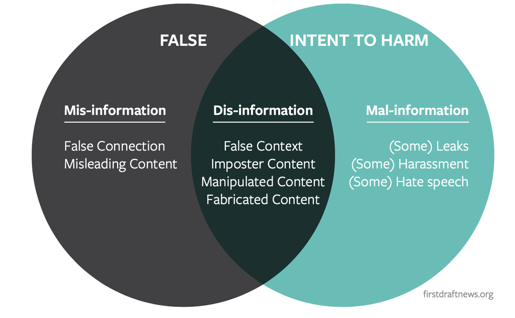

## Disinformation

- A number of studies have investigated how disinformation spreads in social media in multiple languages (Lopez, Vasu, and Gallemore 2020; Sharma et al. 2020), but always within the same language.
- To our knowledge, no studies have thus far investigate the spread of disinformation across different languages.

## The current study

- Two main political figures in two countries that are known for disinformation spreading:
  - Donald Trump in the United States
  - Jair Bolsonaro in Brazil
- Focus our data analysis on the year of 2020, using tweets from previous years by both leaders as a baseline

## The current study

While most governments around the world have reacted immediately to the pandemic by implementing and enforcing measures that reduced the spread of COVID-19, Trump and Bolsonaro have done the opposite, which caused a split of opinions within both countries.

Our question is whether there are parallels to the way they communicate to their elector base through tweets, looking at both American English and Brazilian Portuguese data.

## The current study

[figure not shown]

## Our questions

1. Are the language patterns in American English and Brazilian Portuguese tweets by Trump and Bolsonaro similar over time?
2. Is there a chronological pattern of “spread” from one language to another?

## Corpus

- Tweets from Jair Bolsonaro and Donald Trump, excluding retweets.
- Baseline: tweets before 2020

Trump tweets were retrieved from the Trump Twitter Archive, since Trump’s account was suspended on January 8, 2021.

Bolsonaro’s tweets were collected using Twitter’s API through the academictwitteR R package (Barrie & Chun-ting Ho, 2021).

| author | tokens before 2020 | tokens in 2020 |
| --- | --- | --- |
| Bolsonaro | 12,316 | 108,411 |
| Trump | 882,575 | 263,615 |

## Keyword analysis

The two corpora were split into two each:

1. a baseline, with tweets that were published before January 1, 2020
2. the main corpus, with tweets from January 1, 2020 to December 31, 2020.

We calculate corpus frequency keyness using the log-likelihood statistic (Scott and Tribble 2006) to identify words that are strongly associated with the content of the tweets from the year of 2020 (compared to the baseline corpora).

## Exploratory visualization

Interactive visualization tool:

- https://picoral.shinyapps.io/lexical-comparison-tweets-trump-bolsonaro

Frequency of tweets per week that contain search words in English and Portuguese in Trump’s and Bolsonaro’s Twitter accounts

## Exploratory visualization

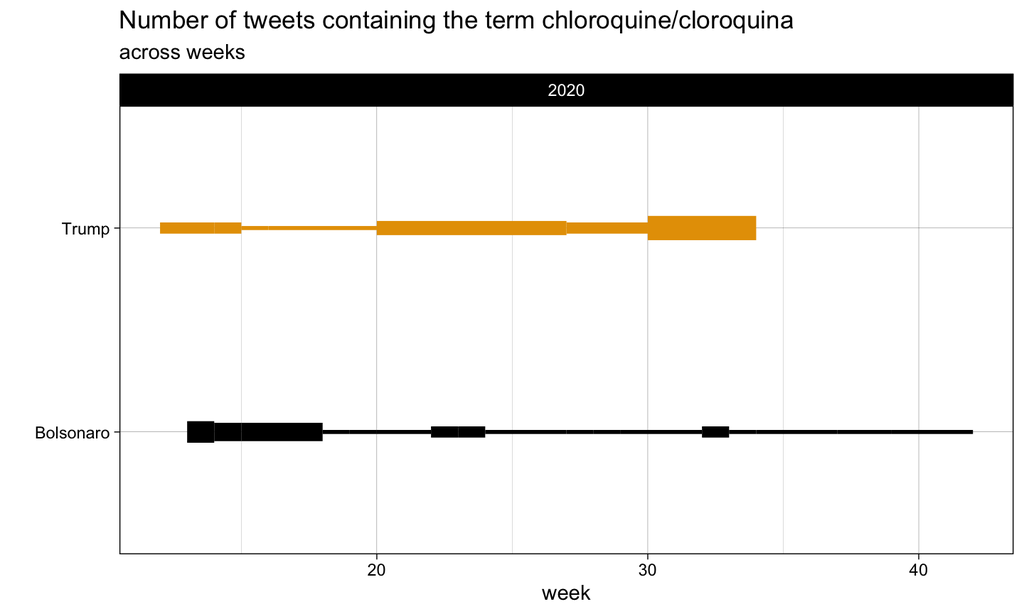

## Example

| Trump's Tweet |  |
| --- | --- |
| ...of 2,541 patients hospitalized between March 10 and May 2, 2020 across the system’s six hospitals, the study found 13% of those treated with hydroxychloroquine alone died compared to 26.4% not trea… | Monday 6 July 2020 |

| Bolsonaro's Tweet |  |
| --- | --- |
| - @FoxNews mostra estudos sobre a eficácia da Hidroxicloroquina no combate ao Coronavírus. https://t.co/C0qbQmqDez | Saturday 18 July 2020 |

[fox news link](https://www.foxnews.com/politics/hydroxychloroquine-helped-save-coronavirus-study)

## Exploratory visualization

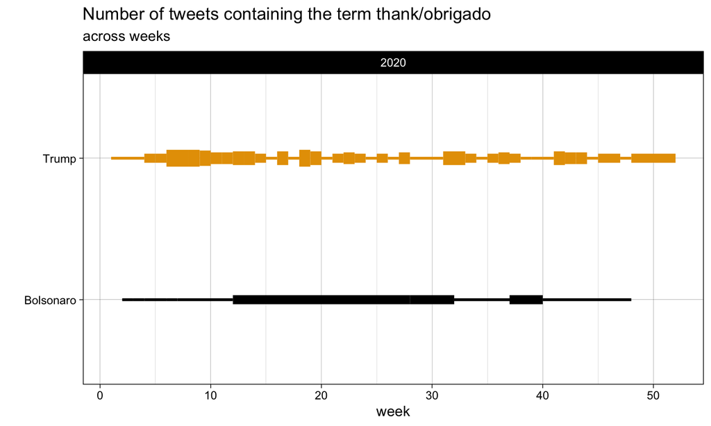

## Example

| Trump's Tweet |  |
| --- | --- |
| Very true, thank you Ted & John. I love Texas! https://t.co/NoWTheat7Z | Friday 7 February 2020 |

| Bolsonaro's Tweet |  |
| --- | --- |
| Muito obrigado meu AGRESTE. Brasil acima de tudo, Deus acima de todos!. No YouTube: https://t.co/brpzLpltNZ https://t.co/IjPS1sJ8dN | Saturday 3 October 2020 |

## Linear Regression

> Is there a statistical relationship between tweets by Bolsonaro in any week and tweets by Trump in the previous week?
- Linear regression:
  - response variable: the total number of tweets by Bolsonaro containing these terms each week in the year of 2020
  - predictors: lexical item and the total number of tweets in the previous week containing these terms by Trump
- Terms selected by the keyword analysis (i.e., chloroquine, thanks, virus, fraud, freedom, left in English paired with cloroquina, obrigado, vírus, fraude, liberdade, esquerda in Portuguese)

## Linear Regression

- Bolsonaro posts an average of 0.82 tweets containing the selected lexical items every week of the year 2020.
- The previous trump counts have a significant effect on what Bolsonaro tweets in a week, with an increase of .12 tweets for every 1 tweet by Trump.
- About 8 tweets with a term by Trump has the effect of one Tweet with an equivalent term by Bolsonaro in the following week
- The model explains 27% of the variance in the data.

## Linear Regression

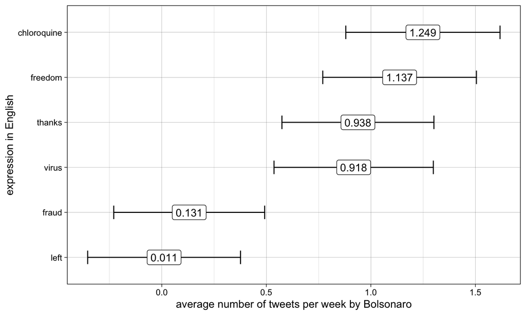

## Revisiting keyword analysis

> What can we learn from Machine Learning?
- Feature selection is an important step in both machine learning methods and corpus linguistics.
- R package Boruta (Kursa and Rudnicki 2010)
  - feature selection algorithm for finding significant relevant variables
  - iteratively runs a Random Forest classification algorithm
  - For our specific data, the classification was binary: (pre-pandemic vs. pandemic)

## More on Boruta

- Random Forests is an ensemble method in which classification is performed by voting of multiple unbiased weak classifiers — decision trees
- Loss of accuracy of classification caused by the random permutation of attribute values is computed separately for all trees in the forest
- Z score as the importance measure (it takes into account the fluctuations of the mean accuracy loss among trees in the forest)
  - computed by dividing the average loss by its standard deviation

[Kursa and Rudnicki (2010)](https://www.jstatsoft.org/article/view/v036i11/)

## Boruta results

Tokens selected by Boruta with categorical presence in the pandemic corpus.

| token | tweet count |
| --- | --- |
| telegram | 146 |
| doses | 130 |
| covid | 104 |
| vacinas | 102 |
| vacina | 95 |
| pandemia | 76 |
| fio | 51 |

## Boruta results

- Pre-pandemic lexical items:

entrevista, abraço, não, é, pela, brasil, muito, mas, esquerda, minha, amor, pesquisa, vamos, pt, lula, foro, ñ

- Pandemic lexical items:

auxílio, emergencial, títulos, combustíveis, leitos, ponte, equipamentos, entregues, alimentos, apreensão, obra, ações, transporte, km, água, profissionais, tratamento, obras, empresas, famílias, operação, meio, vidas, redes, bilhões, youtube, novas, municípios, unidades, milhões, informações, vida, casa, pessoas, recursos, impostos, saúde, ministro, região, link, presidente, povo, foram, federal, todos

## Next Steps

- Include election fraud disinformation in the analysis?
- Instead of frequency, use one-hot encoding
  - presence vs. absence of lexical item
  - avoid problem of collapsing data
- Multivariate time series algorithms?
  - We are not interested in forecasting but in interpreting the model
  - Volume of data